# Image Classification mit Google Quickdraw

Von Tristan Emig, Benno Grimm & Marcel Mertens

# Fahrplan

- Idee
- Datenset
- Datenaufbereitung
- Überblick Neuronale Netze & CNN
- Ergebnisse

# Idee

## Google Quickdraw

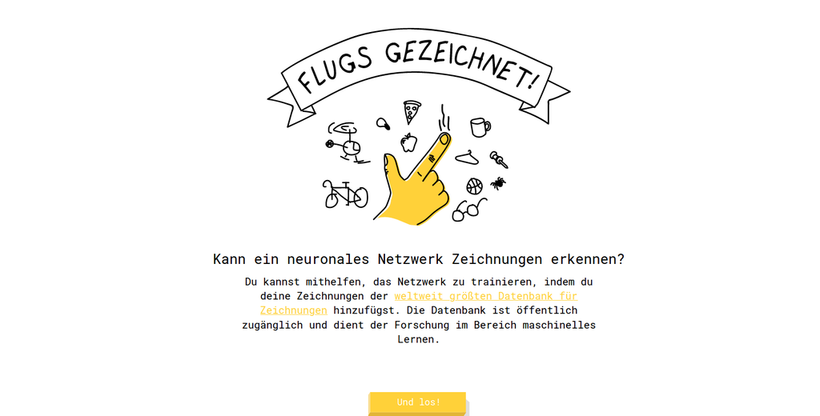

(Quelle: Screenshot https://quickdraw.withgoogle.com/)

# Datenset

- Suche nach geeigneten Datensets
- Als Anfänger => Suchen eines einfachen Datensets

### Auswahlkriterien:

- Ausschließen von Fotografien
- Ausschließen von Zeichnungen mit Farbe
- Ausschließen von zu komplexen Zeichnungen

=> Nutzen des Quickdraw Datensets

# Datenaufbereitung

- Rohdaten enthalten zeilenweise Informationen über einzelne, von Menschen gezeichneten, Doodles
- Daten enthalten auch Zeitinformationen, wann was gezeichnet wurde

### Aufbau eines Datensatzes

(nach Google, vereinfacht)

```
"drawing": [
  [  // First stroke
    [x0, x1, x2, x3, ...],
    [y0, y1, y2, y3, ...],
    [t0, t1, t2, t3, ...]
  ],
  [  // Second stroke
    [x0, x1, x2, x3, ...],
    [y0, y1, y2, y3, ...],
    [t0, t1, t2, t3, ...]
  ],
  ... // Additional strokes
]
```

### Aufbereitung

- Zeitinformationen ignorieren
- Bilder auf gleiche Größe transformieren

### Plotten der Rohdaten

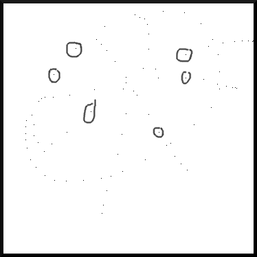

### Füllen der Linien (Strokes)

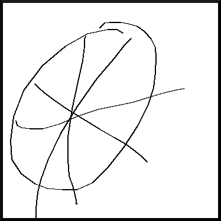

### Zugeschnittene und skalierte Zeichnungen

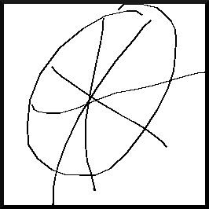

### Unser fertiges Datenformat

- Bilder sollen eine Größe von `256x256` Pixeln haben
- Zur Speicherung: Nutzen einer `256x256` Matrix
- Eine `1` repräsentiert ein schwarzes Pixel
- Eine `0` repräsentiert ein weißes Pixel

# Überblick Neuronale Netze und CNN

- Es gibt eine Vielzahl an Neuronalen Netzen  
  => Herausfinden, welches sich für uns eignet

## Einige Beispiele

| - Perceptron (P) | - Restricted BM (RBM) |
| --- | --- |
| - Feed Forward (FF) | - Deep Beliefe Network (DBN) |
| - Radial Basis Network (RBF) | - Deep Convolutional Network (DCN) |
| - Deep Feed Forward (DFF) | - Deconvolutional Network (DN) |
| - Recurrent Neural Networks (RNN) | - Deep Convolutional Inverse Graphics Network (DCIGN) |
| - Long / Short Term Memory (LSTM) | - Generative Adversarial Network (GAN) |
| - Gated Recurrent Unit (GRU) | - Liquid State Machine (LSM) |
| - Auto Encoder (AE) | - Extreme Learning Machine (ELM) |
| - Variational AE (VAE) | - Echo State Network (ESN) |
| - Denoising AE (DAE) | - Deep Residual Network (DRN) |
| - Sparse AE (SAE) | - Kohonen Network (KN) |
| - Markov Chain (MC) | - Support Vector Machine (SVM) |
| - Hopfield Network (HN) | - Neural Turing Machine (NTM) |
| - Boltzmann Machine (BM) | - Convolutional Neural Network (CNN) |

### Perceptron

- Perceptron ist ein einzelnes Neuron
- Bildet die Grundlage für größere Netze

### Schaubild Perceptron

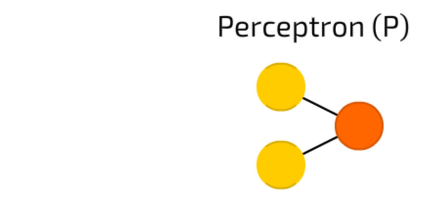

(Quelle: https://towardsdatascience.com/the-mostly-complete-chart-of-neural-networks-explained-3fb6f2367464)

### Feed Forward Netze (FF)

- Alle Knoten vernetzt
- Daten werden durch verschiedene Schichten (Layer) gegeben
- Schichten zwischen Eingabe und Ausgabe sind "hidden Layer"
- Netze dieser Art werden durch "Backpropagation" oder auch "Rückpropagierung" trainiert  
  => Überwachtes Lernverfahren (externer Lehrer kennt zu jedem Zeitpunkt einer Eingabe die gewünschte Ausgabe)

### Schaubild Feed Forward Netze

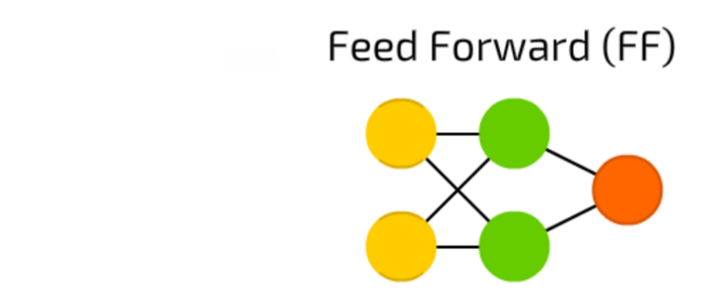

(Quelle: https://towardsdatascience.com/the-mostly-complete-chart-of-neural-networks-explained-3fb6f2367464)

### Mögliche Netze für die Klassifizierung

- Feed Forward Netze
- Deep Feed Forward Netze
- Autoencoder
- **Deep Convolutional Networks**

### Schaubild Deep Convolutional Networks

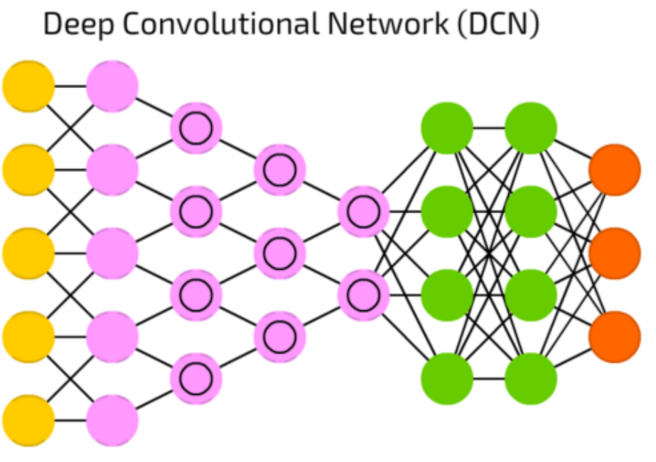

(Quelle: https://towardsdatascience.com/the-mostly-complete-chart-of-neural-networks-explained-3fb6f2367464)

### Convolutional Neuronal Networks (CNN)

- werden als "Stars" der künstlichen Neuronalen Netze betrachtet
- Besitzen verschiedene Schichten
- Am Anfang werden die Eingabedaten komprimiert und vereinfacht (Pooling-Layer)
- Werden für Erkennung und Klassifizierung verwendet
- Sind eine Sonderform mehrlagiger Perceptrons

### Funktion von CNNs bei Bildern

- Aufteilung in kleinere Ausschnitte
- weitere Schichten erkennen Muster

Beispiel:

1. Schicht: Linien
2. Schicht: Farbverläufe
3. Schicht: Formen
4. Schicht: Objekte

### Schaubild zur Funktionsweise von CNNs

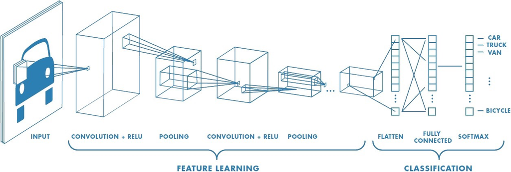

(Quelle: https://medium.com/@RaghavPrabhu/understanding-of-convolutional-neural-network-cnn-deep-learning-99760835f148)

### Vorteile

- Können eine Matrix als Eingabe verwenden (viele NNs brauchen einen Vektor)
- Können verwendet werden um Objekte zu klassifizieren

### Nachteil

- Als Sonderform von FF-Netzen: Fehlerraten von Schichten müssen minimiert werden

# Ergebnisse

- Daten des Datenset werden erkannt (im `.ndjson`-Format)
- Aus `.ndjson`-Dateien des Datensets können `.png`-Dateien erstellt und erkannt werden
- Handgemalte Bilder können erkannt werden  
  => Bilder müssen dazu im Grayscale gemalt werden und eine Größe von `256x256` Pixeln haben

## Error rate over trained sample size

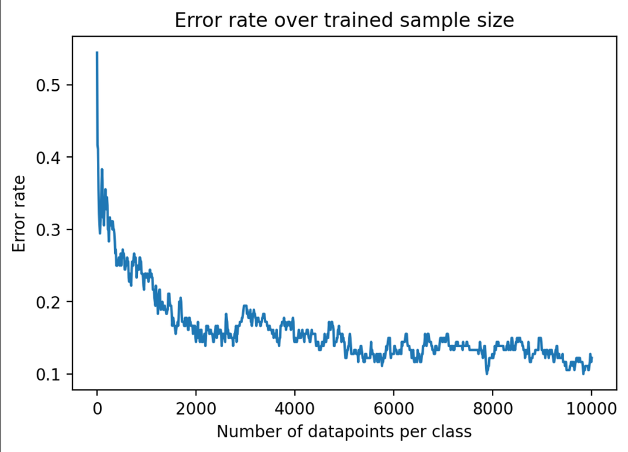

(Quelle: Eigene Darstellung)

## Confusionmatrix mit normalisierten Werten

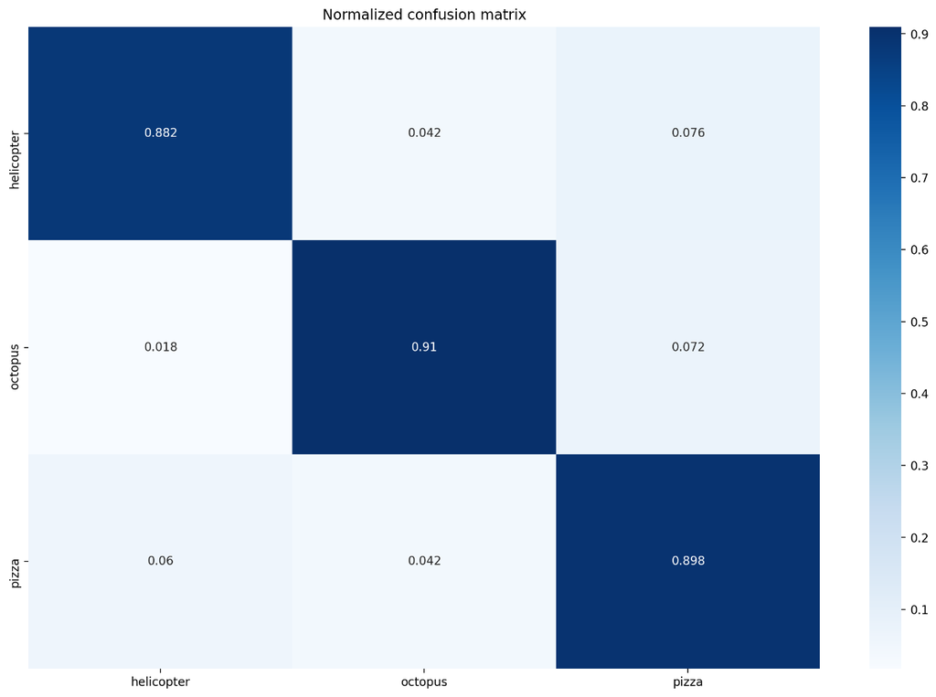

(Quelle: Eigene Darstellung)